# CONSUMER HISTORY: Predicting USA Gros Domestic Product (GDP)

Author: Thiago Tanure Andozia

# GO TO TOP

**In this document, you will find time series models to predict USA Gros Domestic Product (GDP).**

`The time series will be generated by the column "GDP".` `Also, we will try to extrapolate with the data from the Unemployment column.`

*Important:*  
`We will create the time series ending in late 2019.`

*What we will have:* `The extrapolation of the expectation of GPD by it-self and with a scenario with unemployment as a predictor.`

```r
# Packages
lista_pack2 <- c("forecast","ggplot2","urca","lmtest","dplyr","data.table","seasonal","seasonalview","zoo","stringr")
# install.packages(lista_pack2)
lapply(lista_pack2, require, character.only = TRUE)

# Data path
setwd('C:/Users/ttandozia/Desktop/CONSUMER_HISTORY')


# Dataset
study <- fread('STUDY.csv', sep = ',', colClasses = 'character', header = T)
study <- study %>% dplyr::mutate_at(vars(2:6), ~ as.numeric(str_replace(gsub(c("[$R-]"), "", .), ",", ".")))
study$Unemployment <- round(study$Unemployment,4)*100
```

`The first time serie and some informations about it.`

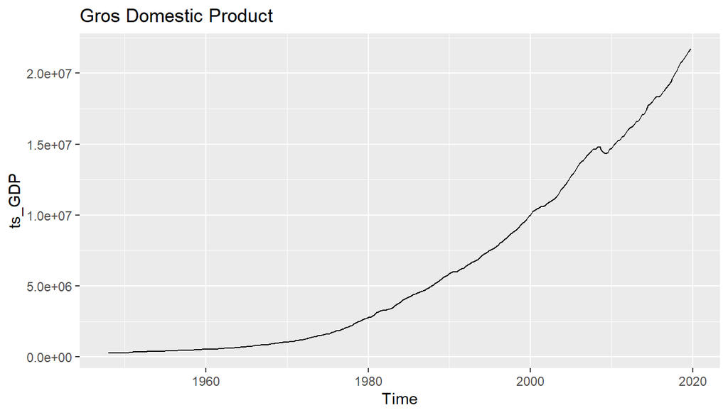

```r
# Generating the time series
ts_GDP <- ts(study$Gross_domestic_product_GDP, start = c(1948,1), end = c(2019,4), frequency = 4)
autoplot(ts_GDP, main = 'Gros Domestic Product')
```

```r
# Mean, median, summary, length
print(paste0('Mean: ',round(mean(ts_GDP),2)))
```

```
## [1] "Mean: 6279515.81"
```

```r
print(paste0('Median: ',round(median(ts_GDP),2)))
```

```
## [1] "Median: 3851380"
```

```r
print(paste0('length: ',length(ts_GDP)))
```

```
## [1] "length: 288"
```

```r
print(summary(ts_GDP))
```

```
##     Min.  1st Qu.   Median     Mean  3rd Qu.     Max.
##   265742   789765  3851380  6279516 10692458 21729124
```

`Graphics`

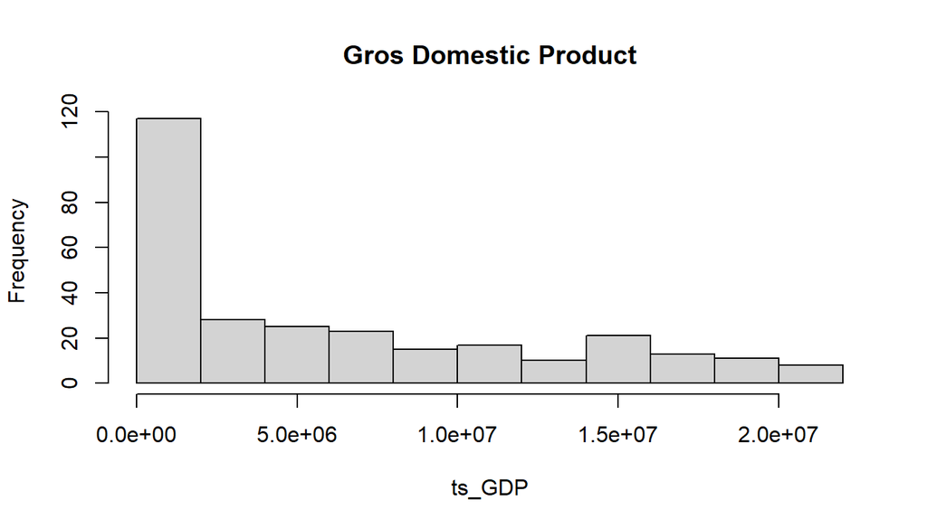

```r
# Graphics
hist(ts_GDP, main = 'Gros Domestic Product')
```

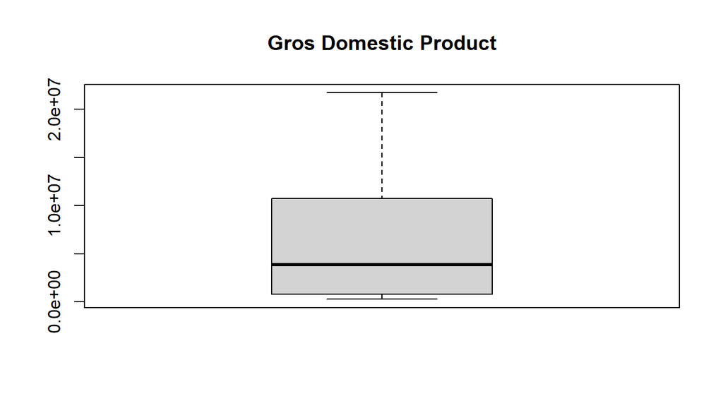

```r
boxplot(ts_GDP, main = 'Gros Domestic Product')
```

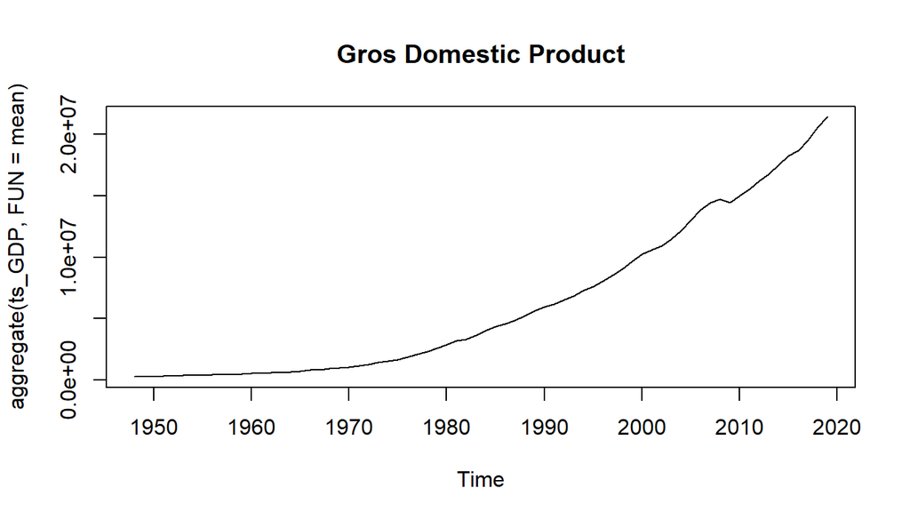

```r
plot(aggregate(ts_GDP, FUN=mean), main = 'Gros Domestic Product')
```

`Note: FUN is the aggregation function. Softened data that is very seasonal.`

# PREDICTIVE AUTO ARIMA

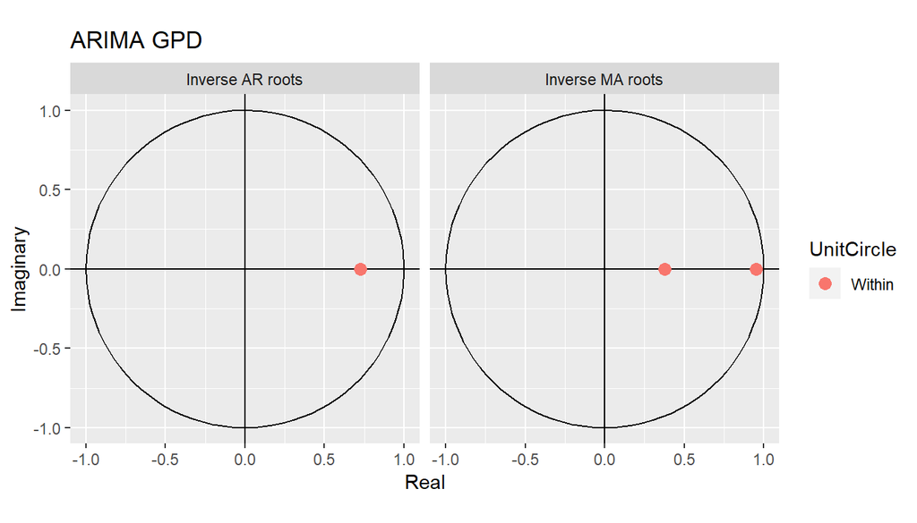

```r
# Predictive time series model
prev <- auto.arima(ts_GDP)

# Analyzing residuals
autoplot(prev, main = 'ARIMA GPD')
```

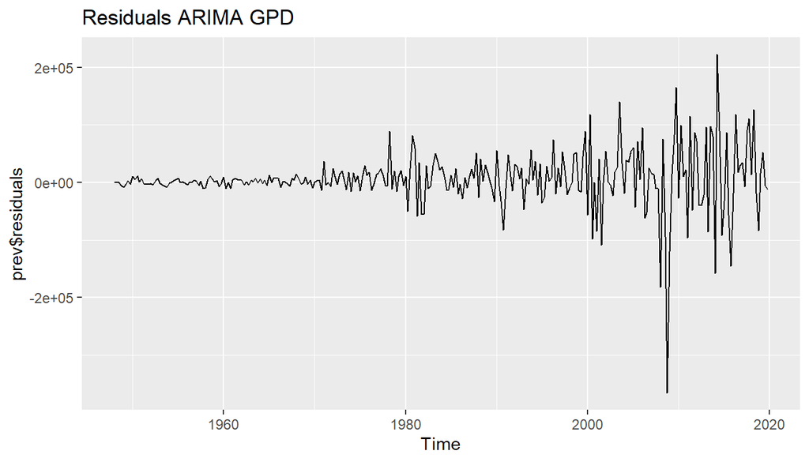

```r
autoplot(prev$residuals, main = 'Residuals ARIMA GPD')
```

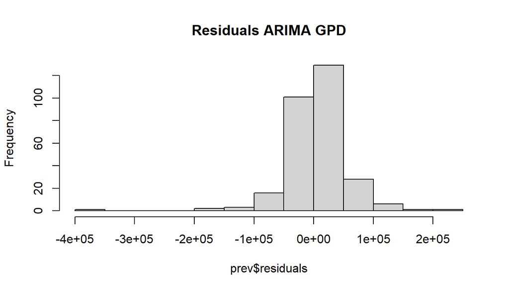

```r
hist(prev$residuals, main = 'Residuals ARIMA GPD')
```

```r
var(prev$residuals,na.rm = T) # Variance. 'na.rm' does not consider NA
mean(as.vector(prev$residuals),na.rm = T)
```

[output not shown]

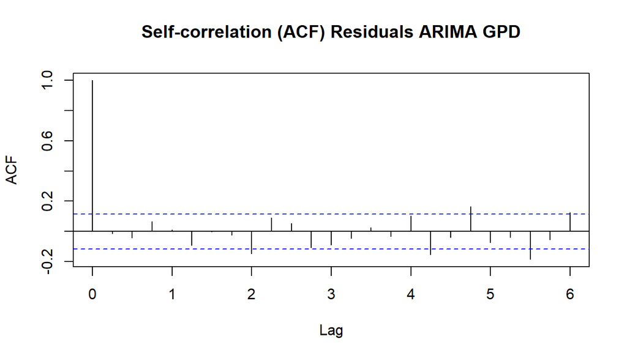

```r
# Self-correlation (acf) and Partial auto-correlation (pacf)
acf(prev$residuals, na.action = na.pass, main = 'Self-correlation (ACF) Residuals ARIMA GPD') # na.action to ignore 'NA'
```

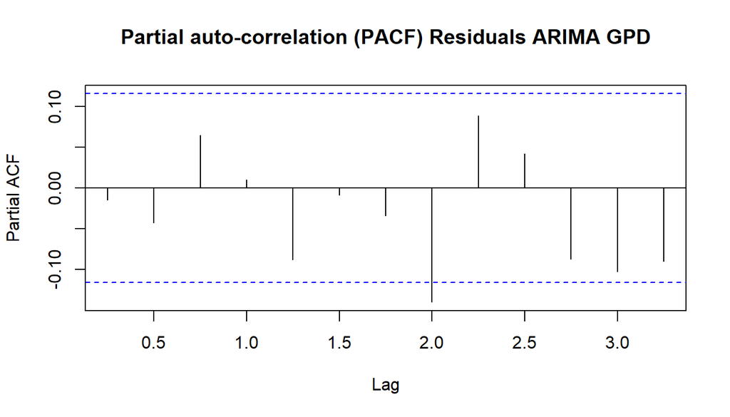

```r
pacf(prev$residuals, na.action = na.pass, lag.max = 13, main = 'Partial auto-correlation (PACF) Residuals ARIMA GPD')
```

`Here we can see another way to analyze residuals:`

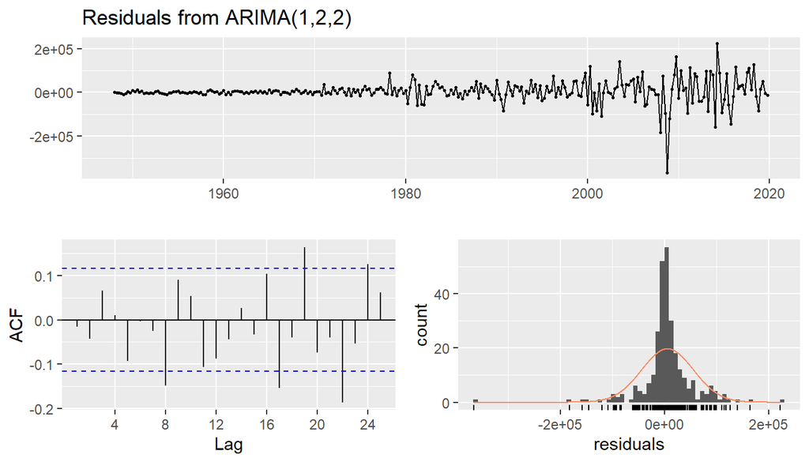

```r
# Special function to check residuals in the model
checkresiduals(prev)
```

ARIMA (1, 2, 2) means that this has:  
- 1 auto-regressive parameter;  
- 2 differentiations from the original series;  
- 2 parameters of moving averages.’

**To see if are normally distributed:**

```r
# Normality test
shapiro.test(prev$residuals)
```

```
##
##  Shapiro-Wilk normality test
##
## data:  prev$residuals
## W = 0.82394, p-value < 2.2e-16
```

`The data does not come from a normal distribution`

# STATIONARITY & DIFFERENTIATIONS

## STATIONARITY

```r
# Stationarity test
x <- ur.kpss(ts_GDP)
print(x)
```

```
##
## #######################################
## # KPSS Unit Root / Cointegration Test #
## #######################################
##
## The value of the test statistic is: 4.4638
```

`This series has a tendency. Probably not stationary.` `The test is greater than 0.05. It shows us that this series is not stationary.`

## DIFFERENTIATIONS

It transforms from non-stationary to stationary

`Function to know how many differentiations are needed`

```r
print(paste0('It is necessary to do ',ndiffs(ts_GDP),' differentiations'))
```

```
## [1] "It is necessary to do 2 differentiations"
```

```r
# 1 differentiation
ts_GDP_1 <- diff(ts_GDP)
x <- ur.kpss(ts_GDP_1)
print(x)
```

```
##
## #######################################
## # KPSS Unit Root / Cointegration Test #
## #######################################
##
## The value of the test statistic is: 3.5597
```

```r
# 2 differentiations
ts_GDP_2 <- diff(ts_GDP_1)
x <- ur.kpss(ts_GDP_2)
print(x)
```

```
##
## #######################################
## # KPSS Unit Root / Cointegration Test #
## #######################################
##
## The value of the test statistic is: 0.0127
```

`After 2 differentiation processes, we managed to transform it into a stationary one.`

`Visually analyzing both (original and after 2 differentiations)`

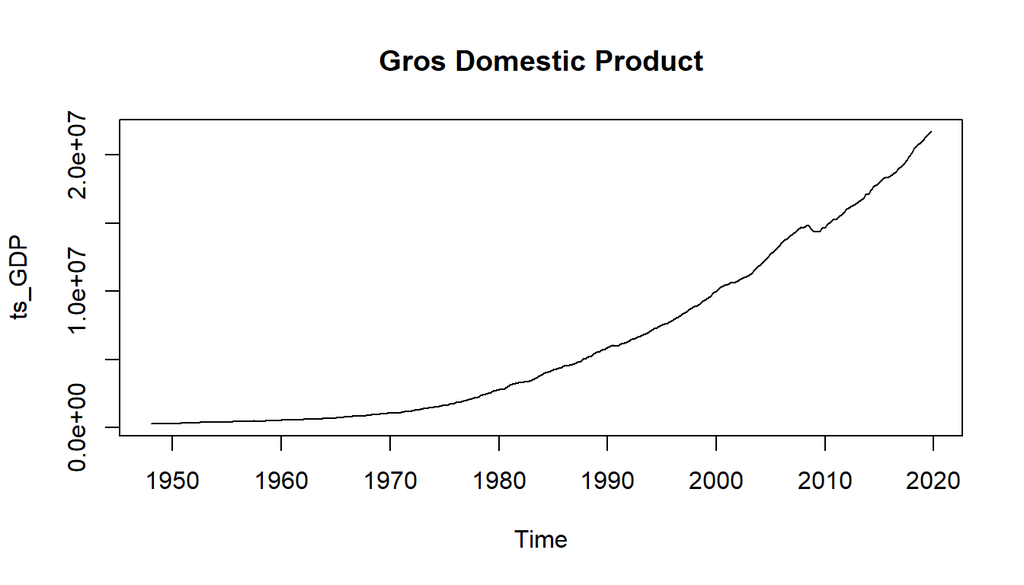

```r
plot(ts_GDP, main = 'Gros Domestic Product')
```

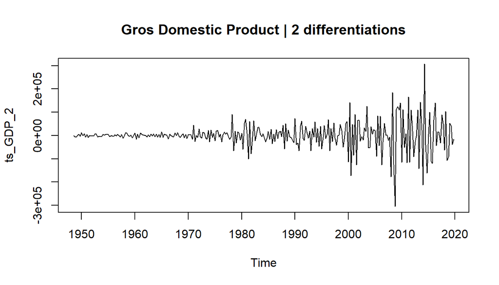

```r
plot(ts_GDP_2, main = 'Gros Domestic Product | 2 differentiations')
```

# SEASONNALITY & TREND

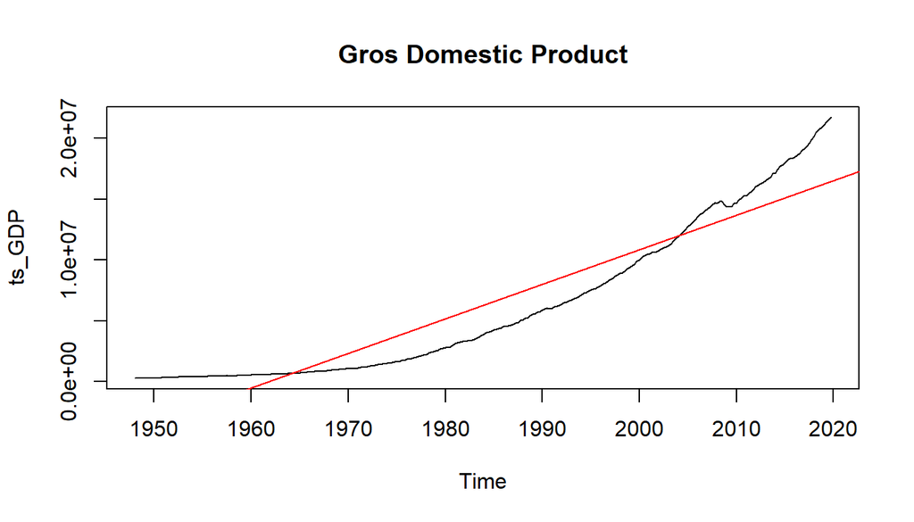

```r
# Seasonality and trend of the normal series
plot(ts_GDP, main = 'Gros Domestic Product')
abline(reg=lm(ts_GDP~time(ts_GDP)), col = 'red')
```

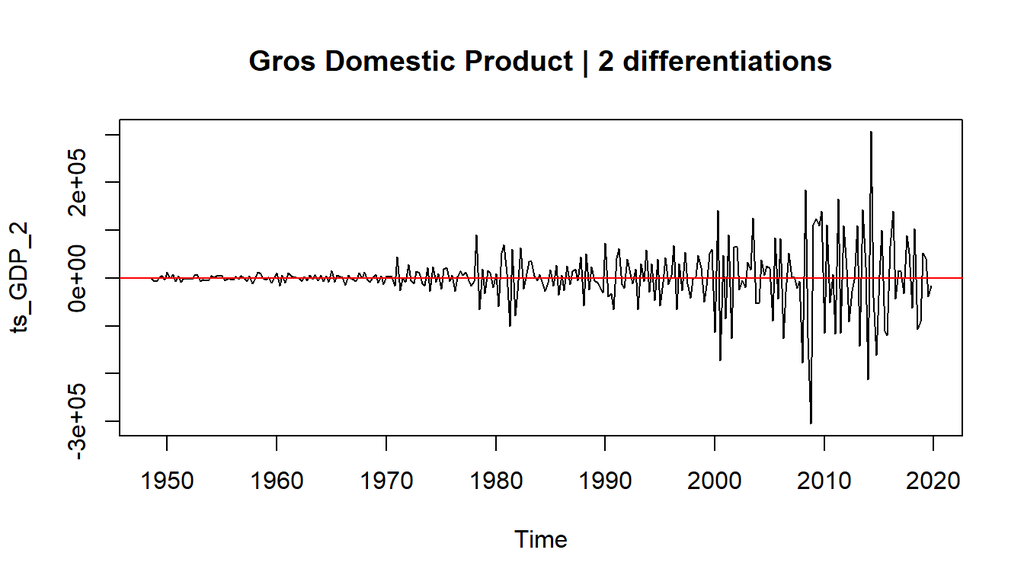

```r
# Seasonality and trend of the 2 differentiations series
plot(ts_GDP_2, main = 'Gros Domestic Product | 2 differentiations')
abline(reg=lm(ts_GDP_2~time(ts_GDP_2)), col = 'red')
```

# DECOMPOSION & BOXCOX TRANSF.

## CLASSICAL DECOMPOSION

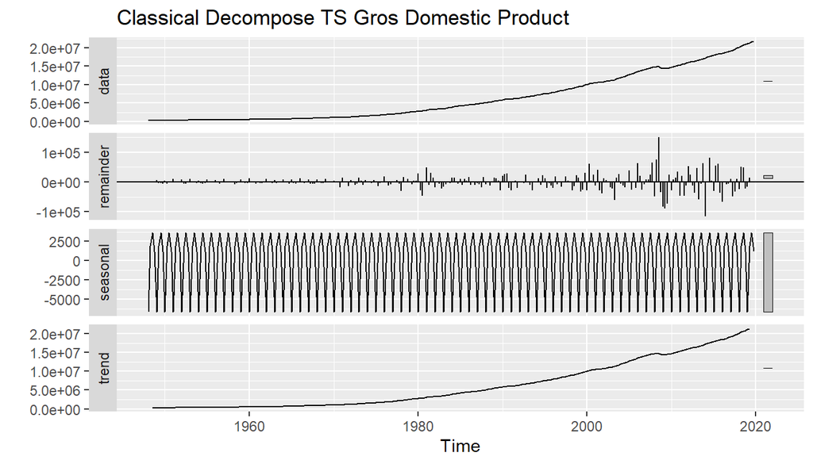

```r
# Classical decomposition of the normal series
normal <- decompose(ts_GDP)
autoplot(normal, main = 'Classical Decompose TS Gros Domestic Product')
```

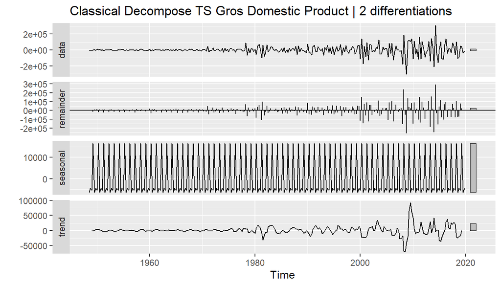

```r
# Classical decomposition of the 2 differentiations series
dif_2 <- decompose(ts_GDP_2)
autoplot(dif_2, main = 'Classical Decompose TS Gros Domestic Product | 2 differentiations')
```

## MSTL DECOMPOSION

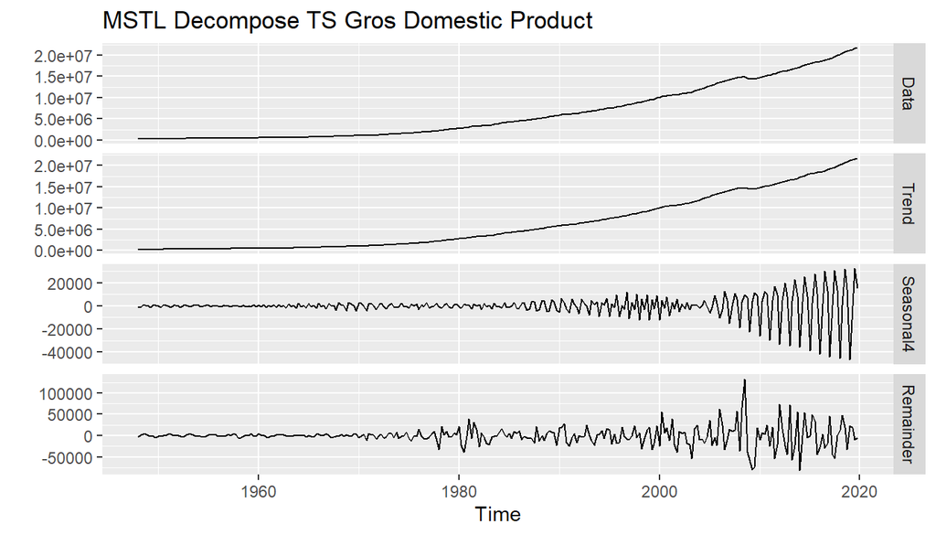

```r
# Mstl decomposition of the normal series
msap_normal <- mstl(ts_GDP)
autoplot(msap_normal, main = 'MSTL Decompose TS Gros Domestic Product')
```

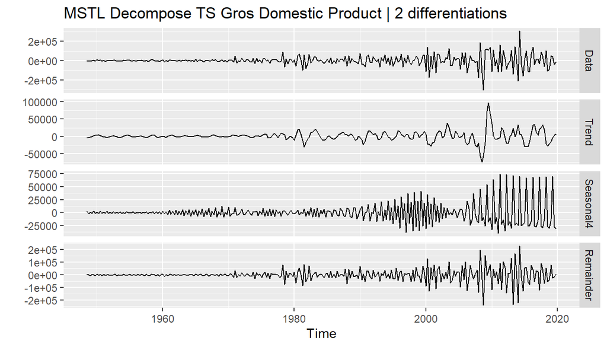

```r
# Mstl decomposition of the 2 differentiations series
msap_dif <- mstl(ts_GDP_2)
autoplot(msap_dif, main = 'MSTL Decompose TS Gros Domestic Product | 2 differentiations')
```

## BOXCOX TRANSFORMATION

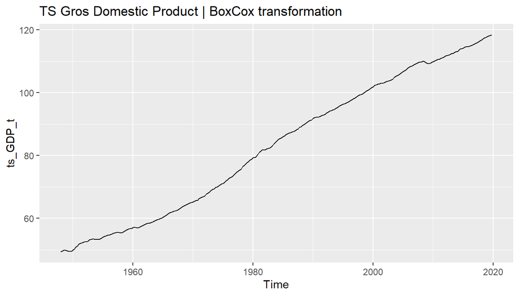

```r
# Transformation

# Normal series
lbd_normal <- BoxCox.lambda(ts_GDP)
print(lbd_normal)
ts_GDP_t <- BoxCox(ts_GDP,lambda = lbd_normal)
autoplot(ts_GDP_t, main = 'TS Gros Domestic Product | BoxCox transformation')
```

[output not shown]

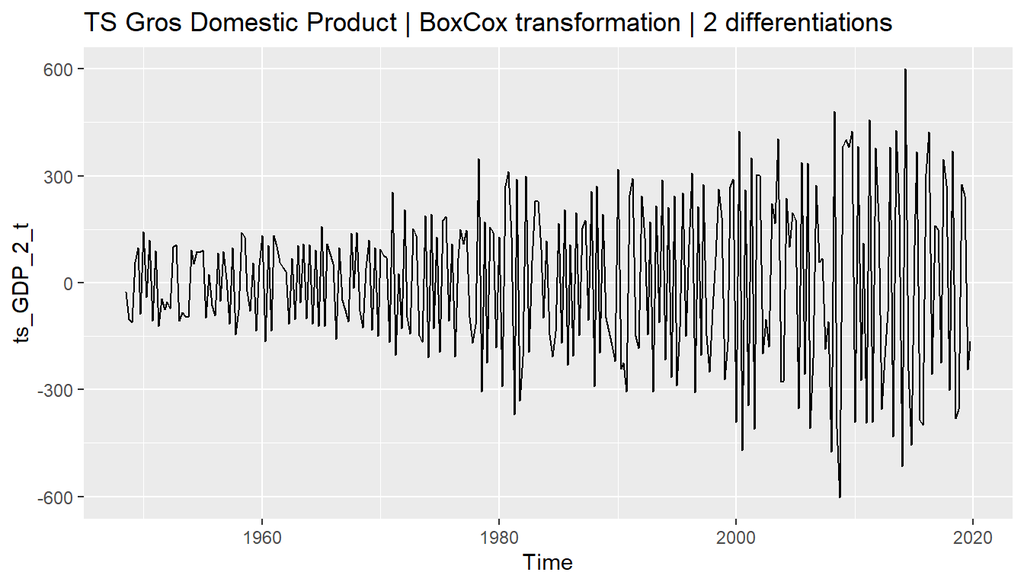

```r
# 2 differentiations series
lbd_dif <- BoxCox.lambda(ts_GDP_2)
print(lbd_dif)
ts_GDP_2_t <- BoxCox(ts_GDP_2,lambda = lbd_dif)
autoplot(ts_GDP_2_t, main = 'TS Gros Domestic Product | BoxCox transformation | 2 differentiations')
```

[output not shown]

## PLOTS TO COMPARE

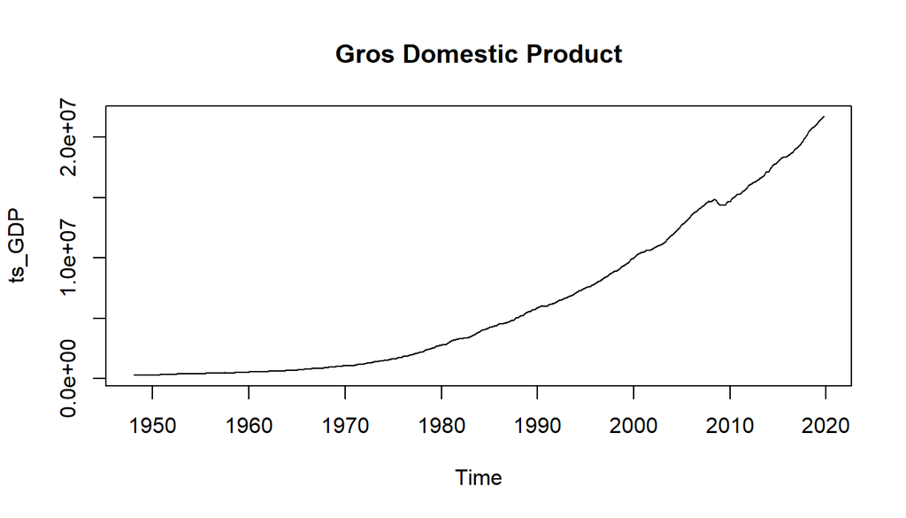

```r
plot(ts_GDP, main = 'Gros Domestic Product')
```

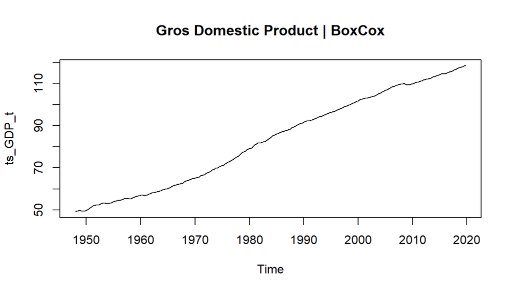

```r
plot(ts_GDP_t, main = 'Gros Domestic Product | BoxCox')
```

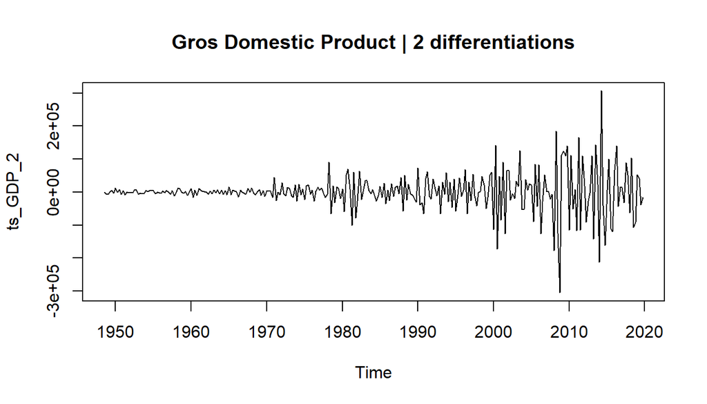

```r
plot(ts_GDP_2, main = 'Gros Domestic Product | 2 differentiations')
```

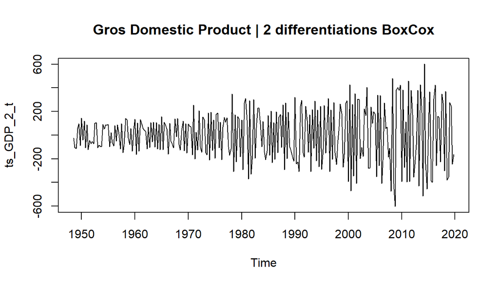

```r
plot(ts_GDP_2_t, main = 'Gros Domestic Product | 2 differentiations BoxCox')
```